# deca-dada2_16s

Dylan Barth

2025-12-09

## Desert Ecology Community Assembly (DECA) dada2 analysis

This document contains the pipeline to process the DECA dataset starting from QC through OTU generation and taxonomic classification. This process mostly relies on dada2 to correct errors in reads before assigning ASVs to individual sequences and quantifying their abundance. This process is incredibly computationally expensive to run on this dataset, which consists of just under 1000 environmental microbiome samples. For that reason, computationally expensive sections of the pipeline have been commented out and replaced with loading intermediate files.

####Import Metadata

```r
##import metadata
meta <- read_csv('raw_data/Raw_Seq_Files_and_Metadata_V2.csv')
```

```
## ──────────────────────────────────────────────────────── Delimiter: "," chr
## (9): R1, R2, SampleDate, PlotNr, Microhabitat, Surface_Subsurface, Grass... lgl
## (2): ...10, ...11
```

```r
meta <- meta %>% mutate(SampleID=str_remove(R1, "\\_L001_R1_001.fastq.gz$")) %>% as.data.frame()
rownames(meta) <- meta$SampleID

##check out sample distribution
##first by microhabitat
meta %>% group_by(Microhabitat) %>% summarize(count=n())
```

```
## # A tibble: 7 × 2
##   Microhabitat count
##   <chr>        <int>
## 1 Neg_Control      1
## 2 Pos_Control1     1
## 3 Pos_Control2     1
## 4 SG             248
## 5 SI             247
## 6 SSG            247
## 7 SSI            244
```

```r
##then by timepoint
meta %>% group_by(SampleDate) %>% summarize(count=n())
```

```
## # A tibble: 10 × 2
##    SampleDate   count
##    <chr>        <int>
##  1 Aug_2023       160
##  2 Aug_2024       153
##  3 Feb_2023       160
##  4 Feb_2024       159
##  5 Jul_2022        40
##  6 Neg_Control      1
##  7 Nov_2022       160
##  8 Nov_2023       154
##  9 Pos_Control1     1
## 10 Pos_Control2     1
```

```r
##then by experimental condition
meta %>% group_by(Treatment) %>% summarize(count=n())
```

```
## # A tibble: 12 × 2
##    Treatment    count
##    <chr>        <int>
##  1 Baseline        40
##  2 Control        116
##  3 N              116
##  4 N+P            115
##  5 N+P+Water      120
##  6 N+Water        120
##  7 Neg_Control      1
##  8 P              121
##  9 P+Water        118
## 10 Pos_Control1     1
## 11 Pos_Control2     1
## 12 Water          120
```

We start by importing the data and showing the distribution of samples across variables.

####Quality check some samples

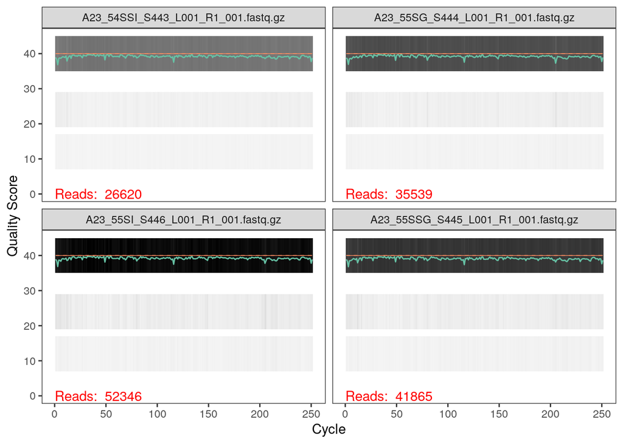

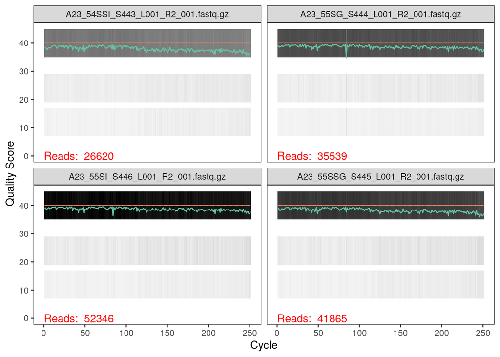

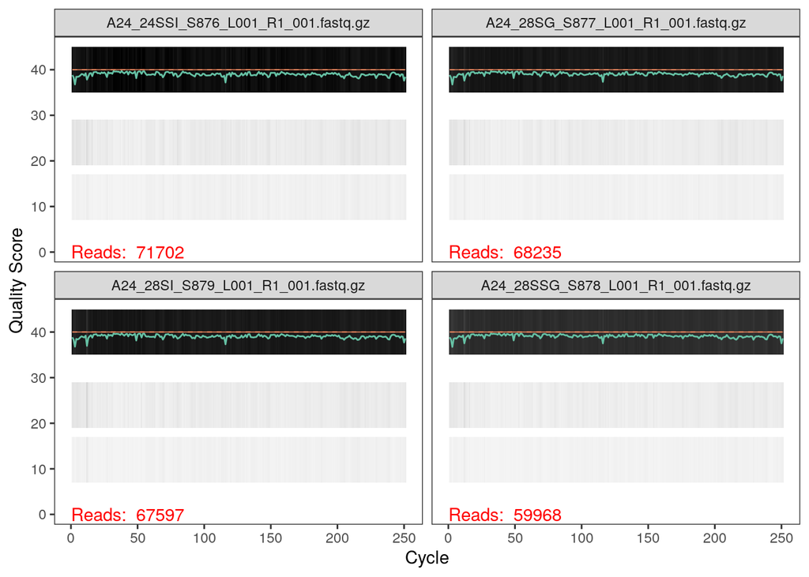

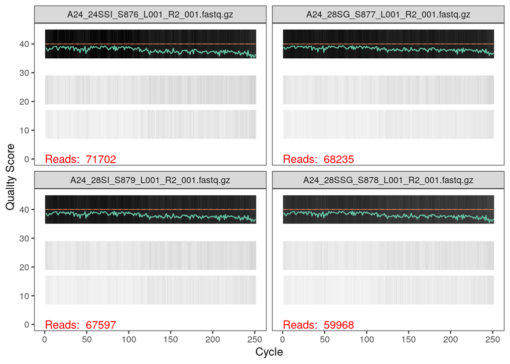

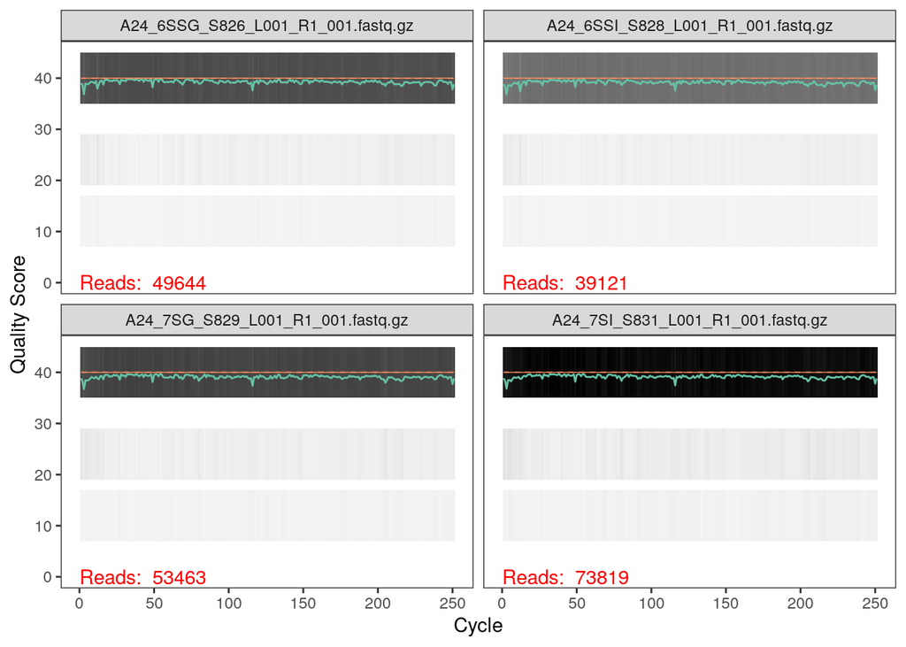

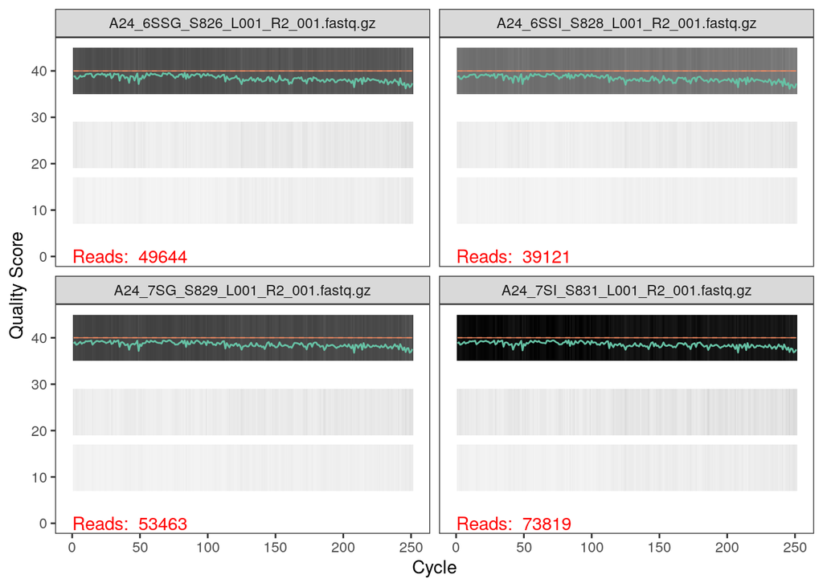

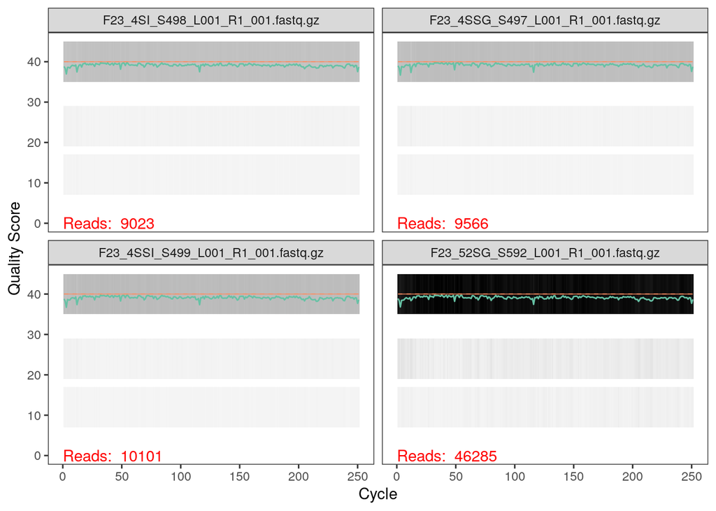

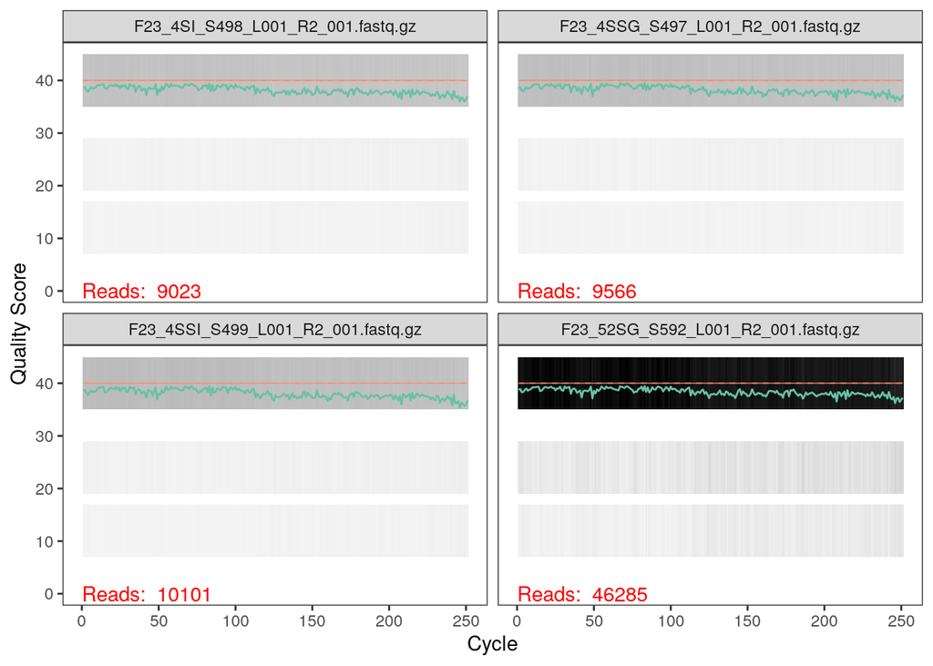

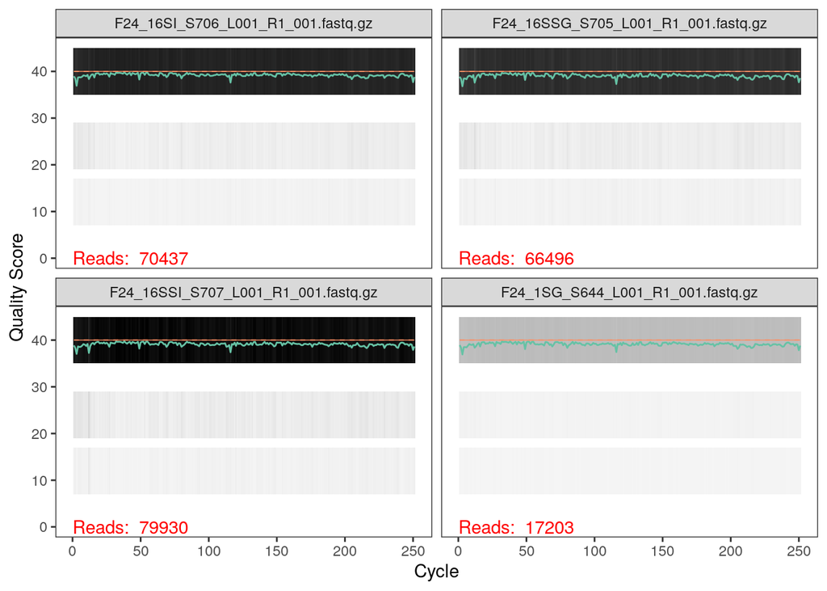

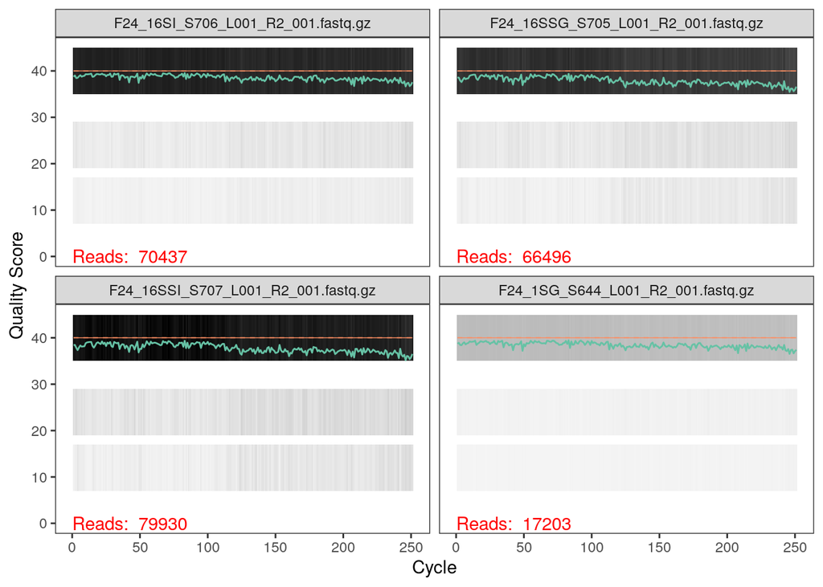

```r
##load forward and reverse reads
fnFs <- paste0('raw_data/250204_Pietrakiak_demultiplxed/',meta$R1)
fnRs <- paste0('raw_data/250204_Pietrakiak_demultiplxed/',meta$R2)

##plot qc
for (i in 1:5){ #
    #png(paste0('figs/dada2_fwd_qc',i,'.png')) #use these lines to save figs to specific output folder
    print(plotQualityProfile(fnFs[(i*100):(i*100 +3)]))
    #dev.off()
    #png(paste0('figs/dada2_rev_qc',i,'.png'))
    print(plotQualityProfile(fnRs[(i*100):(i*100+3)]))
    #dev.off()
}
```

In these graphs you are checking the quality at particular base-pair locations within the read. In our case, we have 250bp reads that have extremely high quality even on reverse reads. Normally you want to ensure you trim off the ends of the reads (trunc_f/r parameters) if they dip below 25-30 on the fastq Read Quality Score. You can also relax the permissible error rates if you need to include more reads (maxEE_f/r; baseline=2)

####Filter out reads with poor quality and trim

```r
##set params according to qc
trunc_f <- 250
trunc_r <- 250
maxEE_f <- 2
maxEE_r <- 2

##filter by params
filtFs <- file.path("raw_data/filt_fastq/", meta$R1)
filtRs <- file.path("raw_data/filt_fastq/", meta$R2)
out <- filterAndTrim(fnFs, filtFs, fnRs, filtRs, truncLen = c(trunc_f, trunc_r),
                     maxN=0, maxEE=c(maxEE_f,maxEE_r), rm.phix=TRUE,
                     compress=TRUE, multithread=TRUE)
```

```
## Some input samples had no reads pass the filter.
```

```r
write.csv(out, 'data/16Sdada2/dada2_reads_filt.csv', row.names = T)
##3 samples removed A24_53SSI_S920_L001_R2_001 A24_52SSI_S916_L001_R2_001 A24_53SSG_S918_L001_R2_001

out <- read_csv('data/16Sdada2/dada2_reads_filt.csv') #load savepoint
out <- out %>% mutate(SampleID=str_remove(...1,"\\_L001_R1_001.fastq.gz$"))
head(out)
```

```
## # A tibble: 6 × 4
##   ...1                                reads.in reads.out SampleID
##   <chr>                                  <dbl>     <dbl> <chr>
## 1 A23_10SG_S360_L001_R1_001.fastq.gz      9433      6549 A23_10SG_S360
## 2 A23_10SI_S362_L001_R1_001.fastq.gz     11871      8080 A23_10SI_S362
## 3 A23_10SSG_S361_L001_R1_001.fastq.gz     7123      4723 A23_10SSG_S361
## 4 A23_10SSI_S363_L001_R1_001.fastq.gz    13183      8527 A23_10SSI_S363
## 5 A23_11SG_S364_L001_R1_001.fastq.gz     12723      8642 A23_11SG_S364
## 6 A23_11SI_S366_L001_R1_001.fastq.gz     34965     23107 A23_11SI_S366
```

```r
summary(out$reads.in)
```

```
##    Min. 1st Qu.  Median    Mean 3rd Qu.    Max.
##       1   21447   41865   48948   66663  292288
```

```r
summary(out$reads.out)
```

```
##    Min. 1st Qu.  Median    Mean 3rd Qu.    Max.
##       0   14355   28159   32651   44236  200697
```

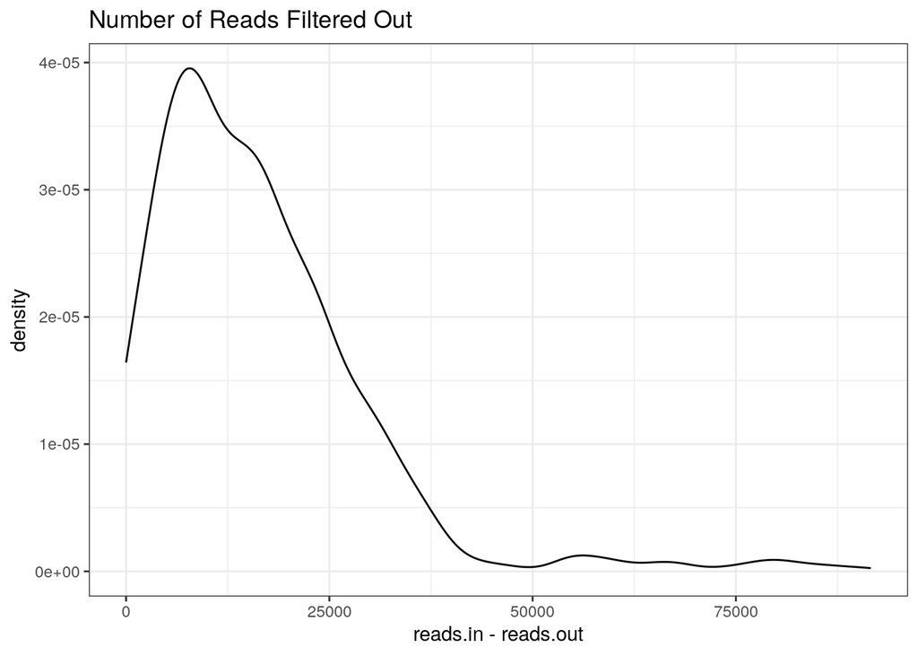

```r
ggplot(out)+
  geom_density(aes(x=reads.in - reads.out))+
  theme_bw()+
  ggtitle('Number of Reads Filtered Out')
```

Here we filter the reads with the parameters from above. A summary table describing the strength of this filter is shown. A plot showing the number of reads filtered out is also shown.

####Run dada2

```r
##prep matched files
filt_fs <- c()
filt_rs <- c()
for (sname in out$SampleID){
    if ( (file.exists(paste0('raw_data/filt_fastq/',sname,'_L001_R1_001.fastq.gz'))) && (file.exists(paste0('raw_data/filt_fastq/',sname,'_L001_R2_001.fastq.gz')))) {
        filt_fs <- c(filt_fs, paste0('raw_data/filt_fastq/',sname,'_L001_R1_001.fastq.gz'))
        filt_rs <- c(filt_rs, paste0('raw_data/filt_fastq/',sname,'_L001_R2_001.fastq.gz'))
    }
}
##learn error rates
err_f <- learnErrors(filt_fs, multithread = T)
```

```
## 102480000 total bases in 409920 reads from 34 samples will be used for learning the error rates.
```

```r
err_r <- learnErrors(filt_rs, multithread = T)
```

```
## 102480000 total bases in 409920 reads from 34 samples will be used for learning the error rates.
```

```r
##run dada2
dadaFs <- dada(filt_fs, err_f, multithread = T)
```

```
## Sample 1 - 6549 reads in 4181 unique sequences.
## Sample 2 - 8080 reads in 5184 unique sequences.
## Sample 3 - 4723 reads in 3564 unique sequences.
## Sample 4 - 8527 reads in 5752 unique sequences.
## Sample 5 - 8642 reads in 5697 unique sequences.
## Sample 6 - 23107 reads in 13422 unique sequences.
## Sample 7 - 7399 reads in 5536 unique sequences.
## Sample 8 - 21106 reads in 13127 unique sequences.
## Sample 9 - 12433 reads in 7855 unique sequences.
## Sample 10 - 17043 reads in 9877 unique sequences.
## Sample 11 - 16364 reads in 11062 unique sequences.
## Sample 12 - 5930 reads in 4489 unique sequences.
## Sample 13 - 8855 reads in 4647 unique sequences.
## Sample 14 - 16601 reads in 8124 unique sequences.
## Sample 15 - 8953 reads in 6576 unique sequences.
## Sample 16 - 17722 reads in 11798 unique sequences.
## Sample 17 - 15188 reads in 9083 unique sequences.
## Sample 18 - 21333 reads in 11729 unique sequences.
## Sample 19 - 16756 reads in 11228 unique sequences.
## Sample 20 - 17823 reads in 11971 unique sequences.
## Sample 21 - 22248 reads in 12804 unique sequences.
## Sample 22 - 10661 reads in 6976 unique sequences.
## Sample 23 - 13078 reads in 9049 unique sequences.
## Sample 24 - 5569 reads in 4260 unique sequences.
## Sample 25 - 12609 reads in 7667 unique sequences.
## Sample 26 - 7081 reads in 4566 unique sequences.
## Sample 27 - 6231 reads in 4744 unique sequences.
## Sample 28 - 11347 reads in 7845 unique sequences.
## Sample 29 - 4427 reads in 3160 unique sequences.
## Sample 30 - 6196 reads in 4107 unique sequences.
## Sample 31 - 4390 reads in 3351 unique sequences.
## Sample 32 - 4953 reads in 3690 unique sequences.
## Sample 33 - 16216 reads in 9435 unique sequences.
## Sample 34 - 21780 reads in 12827 unique sequences.
## Sample 35 - 15624 reads in 10368 unique sequences.
## Sample 36 - 19154 reads in 12608 unique sequences.
## Sample 37 - 22266 reads in 11674 unique sequences.
## Sample 38 - 17735 reads in 8451 unique sequences.
## Sample 39 - 8926 reads in 6128 unique sequences.
## Sample 40 - 14513 reads in 9658 unique sequences.
```

[output cut: 931 more lines]

```
## Sample 972 - 28227 reads in 16201 unique sequences.
## Sample 973 - 32975 reads in 18042 unique sequences.
## Sample 974 - 29704 reads in 15539 unique sequences.
## Sample 975 - 25727 reads in 15613 unique sequences.
## Sample 976 - 27340 reads in 16053 unique sequences.
## Sample 977 - 21501 reads in 11952 unique sequences.
## Sample 978 - 24545 reads in 13480 unique sequences.
## Sample 979 - 29635 reads in 17508 unique sequences.
## Sample 980 - 23430 reads in 14545 unique sequences.
## Sample 981 - 17238 reads in 10146 unique sequences.
## Sample 982 - 16937 reads in 9289 unique sequences.
## Sample 983 - 16962 reads in 10629 unique sequences.
## Sample 984 - 31836 reads in 18257 unique sequences.
## Sample 985 - 10711 reads in 3114 unique sequences.
## Sample 986 - 7390 reads in 2425 unique sequences.
```

```r
dadaRs <- dada(filt_rs, err_r, multithread = T)
```

```
## Sample 1 - 6549 reads in 4324 unique sequences.
## Sample 2 - 8080 reads in 5377 unique sequences.
## Sample 3 - 4723 reads in 3663 unique sequences.
## Sample 4 - 8527 reads in 5917 unique sequences.
## Sample 5 - 8642 reads in 5911 unique sequences.
## Sample 6 - 23107 reads in 14051 unique sequences.
## Sample 7 - 7399 reads in 5686 unique sequences.
## Sample 8 - 21106 reads in 13834 unique sequences.
## Sample 9 - 12433 reads in 8200 unique sequences.
## Sample 10 - 17043 reads in 10276 unique sequences.
## Sample 11 - 16364 reads in 11443 unique sequences.
## Sample 12 - 5930 reads in 4589 unique sequences.
## Sample 13 - 8855 reads in 4883 unique sequences.
## Sample 14 - 16601 reads in 8433 unique sequences.
## Sample 15 - 8953 reads in 6785 unique sequences.
## Sample 16 - 17722 reads in 12163 unique sequences.
## Sample 17 - 15188 reads in 9386 unique sequences.
## Sample 18 - 21333 reads in 12131 unique sequences.
## Sample 19 - 16756 reads in 11622 unique sequences.
## Sample 20 - 17823 reads in 12362 unique sequences.
## Sample 21 - 22248 reads in 13336 unique sequences.
## Sample 22 - 10661 reads in 7263 unique sequences.
## Sample 23 - 13078 reads in 9265 unique sequences.
## Sample 24 - 5569 reads in 4373 unique sequences.
## Sample 25 - 12609 reads in 7922 unique sequences.
## Sample 26 - 7081 reads in 4715 unique sequences.
## Sample 27 - 6231 reads in 4829 unique sequences.
## Sample 28 - 11347 reads in 8095 unique sequences.
## Sample 29 - 4427 reads in 3253 unique sequences.
## Sample 30 - 6196 reads in 4272 unique sequences.
## Sample 31 - 4390 reads in 3438 unique sequences.
## Sample 32 - 4953 reads in 3790 unique sequences.
## Sample 33 - 16216 reads in 9876 unique sequences.
## Sample 34 - 21780 reads in 13435 unique sequences.
## Sample 35 - 15624 reads in 10694 unique sequences.
## Sample 36 - 19154 reads in 13165 unique sequences.
## Sample 37 - 22266 reads in 12200 unique sequences.
## Sample 38 - 17735 reads in 8817 unique sequences.
## Sample 39 - 8926 reads in 6279 unique sequences.
## Sample 40 - 14513 reads in 10064 unique sequences.
```

[output cut: 931 more lines]

```
## Sample 972 - 28227 reads in 16835 unique sequences.
## Sample 973 - 32975 reads in 19182 unique sequences.
## Sample 974 - 29704 reads in 16432 unique sequences.
## Sample 975 - 25727 reads in 16483 unique sequences.
## Sample 976 - 27340 reads in 16854 unique sequences.
## Sample 977 - 21501 reads in 12567 unique sequences.
## Sample 978 - 24545 reads in 14165 unique sequences.
## Sample 979 - 29635 reads in 17735 unique sequences.
## Sample 980 - 23430 reads in 15220 unique sequences.
## Sample 981 - 17238 reads in 10688 unique sequences.
## Sample 982 - 16937 reads in 9749 unique sequences.
## Sample 983 - 16962 reads in 11178 unique sequences.
## Sample 984 - 31836 reads in 19441 unique sequences.
## Sample 985 - 10711 reads in 3347 unique sequences.
## Sample 986 - 7390 reads in 2558 unique sequences.
```

```r
intout <- list(err_f=err_f, err_r=err_r, dadaFs=dadaFs, dadaRs=dadaRs) #pack data into save point
saveRDS(intout, 'data/16Sdada2/dada2_errs.rds')

#intout <- readRDS('data/16Sdada2/dada2_errs.rds') #load save point
#names(intout)
#list2env(intout, .GlobalEnv) #unpack the data into the env, "err_f"  "err_r"  "dadaFs" "dadaRs"

## merge forward and reverse reads
mergers <- mergePairs(dadaFs, filt_fs, dadaRs, filt_rs, verbose=TRUE)
```

```
## 4810 paired-reads (in 194 unique pairings) successfully merged out of 5480 (in 299 pairings) input.
```

```
## 6158 paired-reads (in 230 unique pairings) successfully merged out of 6901 (in 369 pairings) input.
```

```
## 2783 paired-reads (in 134 unique pairings) successfully merged out of 3541 (in 231 pairings) input.
```

```
## 6227 paired-reads (in 226 unique pairings) successfully merged out of 7196 (in 347 pairings) input.
```

```
## 6239 paired-reads (in 233 unique pairings) successfully merged out of 7364 (in 414 pairings) input.
```

```
## 18799 paired-reads (in 572 unique pairings) successfully merged out of 20912 (in 1018 pairings) input.
```

```
## 4707 paired-reads (in 185 unique pairings) successfully merged out of 5766 (in 355 pairings) input.
```

```
## 15642 paired-reads (in 509 unique pairings) successfully merged out of 18415 (in 988 pairings) input.
```

```
## 9339 paired-reads (in 306 unique pairings) successfully merged out of 10624 (in 531 pairings) input.
```

```
## 13743 paired-reads (in 447 unique pairings) successfully merged out of 15310 (in 735 pairings) input.
```

```
## 11480 paired-reads (in 377 unique pairings) successfully merged out of 13695 (in 743 pairings) input.
```

```
## 3589 paired-reads (in 142 unique pairings) successfully merged out of 4502 (in 250 pairings) input.
```

```
## 7541 paired-reads (in 165 unique pairings) successfully merged out of 8079 (in 267 pairings) input.
```

```
## 14633 paired-reads (in 263 unique pairings) successfully merged out of 15544 (in 441 pairings) input.
```

```
## 5723 paired-reads (in 199 unique pairings) successfully merged out of 6981 (in 373 pairings) input.
```

```
## 12808 paired-reads (in 401 unique pairings) successfully merged out of 15302 (in 788 pairings) input.
```

```
## 12215 paired-reads (in 368 unique pairings) successfully merged out of 13596 (in 640 pairings) input.
```

```
## 18169 paired-reads (in 435 unique pairings) successfully merged out of 19619 (in 717 pairings) input.
```

```
## 12197 paired-reads (in 410 unique pairings) successfully merged out of 14329 (in 745 pairings) input.
```

```
## 12514 paired-reads (in 426 unique pairings) successfully merged out of 15115 (in 836 pairings) input.
```

```
## 17877 paired-reads (in 529 unique pairings) successfully merged out of 19928 (in 934 pairings) input.
```

```
## 8136 paired-reads (in 295 unique pairings) successfully merged out of 9110 (in 496 pairings) input.
```

```
## 9182 paired-reads (in 312 unique pairings) successfully merged out of 10626 (in 577 pairings) input.
```

```
## 3184 paired-reads (in 141 unique pairings) successfully merged out of 4244 (in 265 pairings) input.
```

```
## 9649 paired-reads (in 337 unique pairings) successfully merged out of 10980 (in 554 pairings) input.
```

```
## 5421 paired-reads (in 192 unique pairings) successfully merged out of 6075 (in 318 pairings) input.
```

```
## 3977 paired-reads (in 171 unique pairings) successfully merged out of 4745 (in 287 pairings) input.
```

```
## 7780 paired-reads (in 306 unique pairings) successfully merged out of 9340 (in 557 pairings) input.
```

```
## 3065 paired-reads (in 144 unique pairings) successfully merged out of 3490 (in 232 pairings) input.
```

```
## 4355 paired-reads (in 179 unique pairings) successfully merged out of 5128 (in 289 pairings) input.
```

```
## 2704 paired-reads (in 126 unique pairings) successfully merged out of 3283 (in 209 pairings) input.
```

```
## 3158 paired-reads (in 139 unique pairings) successfully merged out of 3723 (in 227 pairings) input.
```

```
## 13024 paired-reads (in 424 unique pairings) successfully merged out of 14353 (in 708 pairings) input.
```

```
## 17622 paired-reads (in 519 unique pairings) successfully merged out of 19668 (in 899 pairings) input.
```

```
## 11643 paired-reads (in 374 unique pairings) successfully merged out of 13216 (in 687 pairings) input.
```

```
## 13801 paired-reads (in 482 unique pairings) successfully merged out of 16407 (in 902 pairings) input.
```

```
## 18791 paired-reads (in 409 unique pairings) successfully merged out of 20334 (in 718 pairings) input.
```

```
## 15704 paired-reads (in 268 unique pairings) successfully merged out of 16602 (in 446 pairings) input.
```

```
## 6080 paired-reads (in 236 unique pairings) successfully merged out of 7342 (in 417 pairings) input.
```

```
## 10382 paired-reads (in 343 unique pairings) successfully merged out of 12294 (in 669 pairings) input.
```

```
## 9614 paired-reads (in 310 unique pairings) successfully merged out of 10892 (in 523 pairings) input.
```

```
## 13324 paired-reads (in 411 unique pairings) successfully merged out of 14775 (in 712 pairings) input.
```

```
## 4245 paired-reads (in 182 unique pairings) successfully merged out of 5084 (in 310 pairings) input.
```

```
## 6559 paired-reads (in 233 unique pairings) successfully merged out of 7794 (in 417 pairings) input.
```

```
## 11386 paired-reads (in 333 unique pairings) successfully merged out of 12928 (in 606 pairings) input.
```

```
## 8984 paired-reads (in 297 unique pairings) successfully merged out of 10290 (in 557 pairings) input.
```

```
## 16083 paired-reads (in 521 unique pairings) successfully merged out of 18441 (in 957 pairings) input.
```

```
## 10574 paired-reads (in 403 unique pairings) successfully merged out of 12438 (in 725 pairings) input.
```

```
## 4109 paired-reads (in 173 unique pairings) successfully merged out of 4768 (in 272 pairings) input.
```

```
## 6824 paired-reads (in 245 unique pairings) successfully merged out of 7777 (in 432 pairings) input.
```

```
## 2967 paired-reads (in 124 unique pairings) successfully merged out of 3540 (in 206 pairings) input.
```

```
## 5661 paired-reads (in 231 unique pairings) successfully merged out of 6935 (in 425 pairings) input.
```

```
## 8328 paired-reads (in 308 unique pairings) successfully merged out of 9456 (in 505 pairings) input.
```

```
## 10964 paired-reads (in 368 unique pairings) successfully merged out of 12213 (in 581 pairings) input.
```

```
## 12521 paired-reads (in 431 unique pairings) successfully merged out of 14347 (in 749 pairings) input.
```

```
## 6013 paired-reads (in 234 unique pairings) successfully merged out of 7213 (in 416 pairings) input.
```

```
## 6613 paired-reads (in 209 unique pairings) successfully merged out of 7342 (in 331 pairings) input.
```

```
## 14293 paired-reads (in 412 unique pairings) successfully merged out of 15806 (in 666 pairings) input.
```

```
## 7624 paired-reads (in 288 unique pairings) successfully merged out of 9271 (in 549 pairings) input.
```

```
## 12663 paired-reads (in 429 unique pairings) successfully merged out of 15289 (in 825 pairings) input.
```

```
## 15118 paired-reads (in 402 unique pairings) successfully merged out of 16760 (in 701 pairings) input.
```

```
## 16322 paired-reads (in 494 unique pairings) successfully merged out of 17919 (in 808 pairings) input.
```

```
## 18807 paired-reads (in 601 unique pairings) successfully merged out of 21438 (in 1110 pairings) input.
```

```
## 13219 paired-reads (in 467 unique pairings) successfully merged out of 15471 (in 860 pairings) input.
```

```
## 12737 paired-reads (in 442 unique pairings) successfully merged out of 14209 (in 717 pairings) input.
```

```
## 27741 paired-reads (in 759 unique pairings) successfully merged out of 30218 (in 1325 pairings) input.
```

```
## 26003 paired-reads (in 766 unique pairings) successfully merged out of 29534 (in 1376 pairings) input.
```

```
## 23530 paired-reads (in 670 unique pairings) successfully merged out of 26258 (in 1199 pairings) input.
```

```
## 18139 paired-reads (in 460 unique pairings) successfully merged out of 19992 (in 791 pairings) input.
```

```
## 18494 paired-reads (in 425 unique pairings) successfully merged out of 20264 (in 764 pairings) input.
```

```
## 25093 paired-reads (in 698 unique pairings) successfully merged out of 28002 (in 1263 pairings) input.
```

```
## 20743 paired-reads (in 602 unique pairings) successfully merged out of 22881 (in 1060 pairings) input.
```

```
## 13383 paired-reads (in 440 unique pairings) successfully merged out of 15020 (in 759 pairings) input.
```

```
## 13117 paired-reads (in 419 unique pairings) successfully merged out of 15014 (in 755 pairings) input.
```

```
## 12597 paired-reads (in 434 unique pairings) successfully merged out of 14635 (in 815 pairings) input.
```

```
## 4748 paired-reads (in 209 unique pairings) successfully merged out of 6011 (in 387 pairings) input.
```

```
## 10671 paired-reads (in 375 unique pairings) successfully merged out of 12076 (in 628 pairings) input.
```

```
## 20256 paired-reads (in 664 unique pairings) successfully merged out of 23044 (in 1133 pairings) input.
```

```
## 15583 paired-reads (in 549 unique pairings) successfully merged out of 18135 (in 1013 pairings) input.
```

```
## 16030 paired-reads (in 535 unique pairings) successfully merged out of 18385 (in 933 pairings) input.
```

```
## 1116 paired-reads (in 77 unique pairings) successfully merged out of 1498 (in 124 pairings) input.
```

```
## 20020 paired-reads (in 543 unique pairings) successfully merged out of 22587 (in 1010 pairings) input.
```

```
## 28974 paired-reads (in 812 unique pairings) successfully merged out of 32778 (in 1486 pairings) input.
```

```
## 26891 paired-reads (in 718 unique pairings) successfully merged out of 29810 (in 1313 pairings) input.
```

```
## 3900 paired-reads (in 160 unique pairings) successfully merged out of 4560 (in 252 pairings) input.
```

```
## 4788 paired-reads (in 189 unique pairings) successfully merged out of 5621 (in 304 pairings) input.
```

```
## 3942 paired-reads (in 161 unique pairings) successfully merged out of 4853 (in 284 pairings) input.
```

```
## 6071 paired-reads (in 243 unique pairings) successfully merged out of 7063 (in 412 pairings) input.
```

```
## 20903 paired-reads (in 420 unique pairings) successfully merged out of 22551 (in 723 pairings) input.
```

```
## 27221 paired-reads (in 623 unique pairings) successfully merged out of 29889 (in 1106 pairings) input.
```

```
## 27307 paired-reads (in 738 unique pairings) successfully merged out of 30505 (in 1342 pairings) input.
```

```
## 37258 paired-reads (in 928 unique pairings) successfully merged out of 42228 (in 1825 pairings) input.
```

```
## 22347 paired-reads (in 538 unique pairings) successfully merged out of 24409 (in 890 pairings) input.
```

```
## 25168 paired-reads (in 649 unique pairings) successfully merged out of 27833 (in 1134 pairings) input.
```

```
## 34830 paired-reads (in 924 unique pairings) successfully merged out of 38934 (in 1730 pairings) input.
```

```
## 19560 paired-reads (in 598 unique pairings) successfully merged out of 23046 (in 1155 pairings) input.
```

```
## 33904 paired-reads (in 612 unique pairings) successfully merged out of 36443 (in 1093 pairings) input.
```

```
## 20160 paired-reads (in 444 unique pairings) successfully merged out of 22027 (in 733 pairings) input.
```

```
## 26529 paired-reads (in 758 unique pairings) successfully merged out of 29562 (in 1344 pairings) input.
```

```
## 13169 paired-reads (in 445 unique pairings) successfully merged out of 15135 (in 823 pairings) input.
```

```
## 21300 paired-reads (in 459 unique pairings) successfully merged out of 22904 (in 760 pairings) input.
```

```
## 31086 paired-reads (in 690 unique pairings) successfully merged out of 33810 (in 1191 pairings) input.
```

```
## 22319 paired-reads (in 623 unique pairings) successfully merged out of 25457 (in 1171 pairings) input.
```

```
## 28201 paired-reads (in 850 unique pairings) successfully merged out of 31828 (in 1484 pairings) input.
```

```
## 33165 paired-reads (in 684 unique pairings) successfully merged out of 35413 (in 1142 pairings) input.
```

```
## 51435 paired-reads (in 884 unique pairings) successfully merged out of 54404 (in 1489 pairings) input.
```

```
## 26885 paired-reads (in 788 unique pairings) successfully merged out of 31017 (in 1530 pairings) input.
```

```
## 44163 paired-reads (in 1180 unique pairings) successfully merged out of 49512 (in 2192 pairings) input.
```

```
## 33968 paired-reads (in 637 unique pairings) successfully merged out of 36172 (in 1075 pairings) input.
```

```
## 25231 paired-reads (in 647 unique pairings) successfully merged out of 27757 (in 1135 pairings) input.
```

```
## 29268 paired-reads (in 806 unique pairings) successfully merged out of 33247 (in 1511 pairings) input.
```

```
## 13200 paired-reads (in 455 unique pairings) successfully merged out of 15443 (in 817 pairings) input.
```

```
## 15761 paired-reads (in 437 unique pairings) successfully merged out of 17423 (in 735 pairings) input.
```

```
## 36405 paired-reads (in 853 unique pairings) successfully merged out of 39353 (in 1403 pairings) input.
```

```
## 31374 paired-reads (in 946 unique pairings) successfully merged out of 35932 (in 1740 pairings) input.
```

```
## 35063 paired-reads (in 989 unique pairings) successfully merged out of 39946 (in 1823 pairings) input.
```

```
## 41469 paired-reads (in 958 unique pairings) successfully merged out of 45298 (in 1727 pairings) input.
```

```
## 44012 paired-reads (in 1043 unique pairings) successfully merged out of 48143 (in 1879 pairings) input.
```

```
## 41394 paired-reads (in 1052 unique pairings) successfully merged out of 46327 (in 1917 pairings) input.
```

```
## 29906 paired-reads (in 817 unique pairings) successfully merged out of 33651 (in 1560 pairings) input.
```

```
## 6594 paired-reads (in 250 unique pairings) successfully merged out of 7438 (in 420 pairings) input.
```

```
## 7745 paired-reads (in 258 unique pairings) successfully merged out of 8665 (in 440 pairings) input.
```

```
## 9169 paired-reads (in 327 unique pairings) successfully merged out of 10853 (in 584 pairings) input.
```

```
## 16090 paired-reads (in 495 unique pairings) successfully merged out of 18819 (in 967 pairings) input.
```

```
## 42641 paired-reads (in 818 unique pairings) successfully merged out of 45150 (in 1336 pairings) input.
```

```
## 24951 paired-reads (in 554 unique pairings) successfully merged out of 27154 (in 971 pairings) input.
```

```
## 32631 paired-reads (in 843 unique pairings) successfully merged out of 36645 (in 1540 pairings) input.
```

```
## 18227 paired-reads (in 538 unique pairings) successfully merged out of 21879 (in 1121 pairings) input.
```

```
## 2849 paired-reads (in 99 unique pairings) successfully merged out of 3451 (in 176 pairings) input.
```

```
## 38055 paired-reads (in 666 unique pairings) successfully merged out of 40746 (in 1143 pairings) input.
```

```
## 32315 paired-reads (in 815 unique pairings) successfully merged out of 36187 (in 1558 pairings) input.
```

```
## 32274 paired-reads (in 813 unique pairings) successfully merged out of 36170 (in 1516 pairings) input.
```

```
## 31660 paired-reads (in 815 unique pairings) successfully merged out of 34335 (in 1375 pairings) input.
```

```
## 50109 paired-reads (in 976 unique pairings) successfully merged out of 53922 (in 1713 pairings) input.
```

```
## 43094 paired-reads (in 1062 unique pairings) successfully merged out of 48474 (in 2090 pairings) input.
```

```
## 31426 paired-reads (in 869 unique pairings) successfully merged out of 35901 (in 1635 pairings) input.
```

```
## 35693 paired-reads (in 737 unique pairings) successfully merged out of 38764 (in 1290 pairings) input.
```

```
## 17130 paired-reads (in 472 unique pairings) successfully merged out of 19121 (in 813 pairings) input.
```

```
## 28247 paired-reads (in 759 unique pairings) successfully merged out of 32330 (in 1465 pairings) input.
```

```
## 14965 paired-reads (in 474 unique pairings) successfully merged out of 17397 (in 910 pairings) input.
```

```
## 29855 paired-reads (in 770 unique pairings) successfully merged out of 32602 (in 1292 pairings) input.
```

```
## 42334 paired-reads (in 1017 unique pairings) successfully merged out of 45638 (in 1650 pairings) input.
```

```
## 23491 paired-reads (in 681 unique pairings) successfully merged out of 27717 (in 1380 pairings) input.
```

```
## 38446 paired-reads (in 985 unique pairings) successfully merged out of 43972 (in 1903 pairings) input.
```

```
## 14517 paired-reads (in 472 unique pairings) successfully merged out of 16028 (in 778 pairings) input.
```

```
## 13499 paired-reads (in 395 unique pairings) successfully merged out of 15527 (in 707 pairings) input.
```

```
## 13612 paired-reads (in 430 unique pairings) successfully merged out of 15977 (in 824 pairings) input.
```

```
## 3645 paired-reads (in 160 unique pairings) successfully merged out of 4434 (in 281 pairings) input.
```

```
## 3414 paired-reads (in 138 unique pairings) successfully merged out of 4123 (in 220 pairings) input.
```

```
## 4471 paired-reads (in 150 unique pairings) successfully merged out of 4929 (in 237 pairings) input.
```

```
## 3726 paired-reads (in 150 unique pairings) successfully merged out of 4557 (in 263 pairings) input.
```

```
## 3984 paired-reads (in 157 unique pairings) successfully merged out of 4837 (in 280 pairings) input.
```

```
## 8432 paired-reads (in 297 unique pairings) successfully merged out of 9804 (in 504 pairings) input.
```

```
## 18588 paired-reads (in 479 unique pairings) successfully merged out of 20084 (in 795 pairings) input.
```

```
## 12951 paired-reads (in 455 unique pairings) successfully merged out of 15248 (in 857 pairings) input.
```

```
## 11099 paired-reads (in 386 unique pairings) successfully merged out of 13189 (in 743 pairings) input.
```

```
## 12344 paired-reads (in 412 unique pairings) successfully merged out of 14263 (in 718 pairings) input.
```

```
## 6805 paired-reads (in 237 unique pairings) successfully merged out of 7512 (in 350 pairings) input.
```

```
## 9130 paired-reads (in 327 unique pairings) successfully merged out of 10902 (in 620 pairings) input.
```

```
## 4375 paired-reads (in 183 unique pairings) successfully merged out of 5184 (in 314 pairings) input.
```

```
## 34875 paired-reads (in 839 unique pairings) successfully merged out of 38022 (in 1422 pairings) input.
```

```
## 38092 paired-reads (in 855 unique pairings) successfully merged out of 41170 (in 1461 pairings) input.
```

```
## 36420 paired-reads (in 1055 unique pairings) successfully merged out of 41199 (in 2045 pairings) input.
```

```
## 40561 paired-reads (in 1108 unique pairings) successfully merged out of 44565 (in 1908 pairings) input.
```

```
## 37527 paired-reads (in 915 unique pairings) successfully merged out of 40927 (in 1602 pairings) input.
```

```
## 43145 paired-reads (in 1066 unique pairings) successfully merged out of 47479 (in 1832 pairings) input.
```

```
## 36984 paired-reads (in 1052 unique pairings) successfully merged out of 42337 (in 2011 pairings) input.
```

```
## 26952 paired-reads (in 728 unique pairings) successfully merged out of 30005 (in 1283 pairings) input.
```

```
## 20134 paired-reads (in 584 unique pairings) successfully merged out of 22417 (in 1008 pairings) input.
```

```
## 29848 paired-reads (in 798 unique pairings) successfully merged out of 33270 (in 1430 pairings) input.
```

```
## 12607 paired-reads (in 417 unique pairings) successfully merged out of 14148 (in 669 pairings) input.
```

```
## 28390 paired-reads (in 904 unique pairings) successfully merged out of 32571 (in 1721 pairings) input.
```

```
## 39692 paired-reads (in 746 unique pairings) successfully merged out of 41744 (in 1203 pairings) input.
```

```
## 35173 paired-reads (in 729 unique pairings) successfully merged out of 38289 (in 1327 pairings) input.
```

```
## 36252 paired-reads (in 1014 unique pairings) successfully merged out of 41083 (in 1914 pairings) input.
```

```
## 32409 paired-reads (in 895 unique pairings) successfully merged out of 35272 (in 1527 pairings) input.
```

```
## 44293 paired-reads (in 996 unique pairings) successfully merged out of 47298 (in 1616 pairings) input.
```

```
## 25641 paired-reads (in 608 unique pairings) successfully merged out of 27938 (in 1053 pairings) input.
```

```
## 33758 paired-reads (in 923 unique pairings) successfully merged out of 36957 (in 1604 pairings) input.
```

```
## 33839 paired-reads (in 940 unique pairings) successfully merged out of 37884 (in 1723 pairings) input.
```

```
## 39069 paired-reads (in 1093 unique pairings) successfully merged out of 42791 (in 1884 pairings) input.
```

```
## 20223 paired-reads (in 650 unique pairings) successfully merged out of 22483 (in 1084 pairings) input.
```

```
## 36339 paired-reads (in 868 unique pairings) successfully merged out of 39038 (in 1439 pairings) input.
```

```
## 37830 paired-reads (in 1087 unique pairings) successfully merged out of 42340 (in 2002 pairings) input.
```

```
## 39356 paired-reads (in 926 unique pairings) successfully merged out of 41959 (in 1472 pairings) input.
```

```
## 43051 paired-reads (in 966 unique pairings) successfully merged out of 46100 (in 1580 pairings) input.
```

```
## 35701 paired-reads (in 1012 unique pairings) successfully merged out of 40108 (in 1919 pairings) input.
```

```
## 36583 paired-reads (in 1061 unique pairings) successfully merged out of 40582 (in 1852 pairings) input.
```

```
## 40134 paired-reads (in 912 unique pairings) successfully merged out of 43698 (in 1541 pairings) input.
```

```
## 45637 paired-reads (in 854 unique pairings) successfully merged out of 48319 (in 1462 pairings) input.
```

```
## 39928 paired-reads (in 1025 unique pairings) successfully merged out of 44008 (in 1885 pairings) input.
```

```
## 20397 paired-reads (in 623 unique pairings) successfully merged out of 22881 (in 1070 pairings) input.
```

```
## 42617 paired-reads (in 1100 unique pairings) successfully merged out of 46839 (in 1889 pairings) input.
```

```
## 26840 paired-reads (in 770 unique pairings) successfully merged out of 30257 (in 1335 pairings) input.
```

```
## 36281 paired-reads (in 995 unique pairings) successfully merged out of 40858 (in 1887 pairings) input.
```

```
## 43032 paired-reads (in 1134 unique pairings) successfully merged out of 48804 (in 2157 pairings) input.
```

```
## 47182 paired-reads (in 724 unique pairings) successfully merged out of 49823 (in 1250 pairings) input.
```

```
## 44790 paired-reads (in 936 unique pairings) successfully merged out of 47732 (in 1560 pairings) input.
```

```
## 40464 paired-reads (in 1114 unique pairings) successfully merged out of 45064 (in 1986 pairings) input.
```

```
## 38509 paired-reads (in 1079 unique pairings) successfully merged out of 42828 (in 1927 pairings) input.
```

```
## 39202 paired-reads (in 925 unique pairings) successfully merged out of 43021 (in 1696 pairings) input.
```

```
## 38758 paired-reads (in 871 unique pairings) successfully merged out of 41906 (in 1528 pairings) input.
```

```
## 32753 paired-reads (in 963 unique pairings) successfully merged out of 36435 (in 1695 pairings) input.
```

```
## 51822 paired-reads (in 1109 unique pairings) successfully merged out of 55503 (in 1897 pairings) input.
```

```
## 28654 paired-reads (in 742 unique pairings) successfully merged out of 31160 (in 1270 pairings) input.
```

```
## 41396 paired-reads (in 910 unique pairings) successfully merged out of 45163 (in 1636 pairings) input.
```

```
## 53597 paired-reads (in 1511 unique pairings) successfully merged out of 59290 (in 2751 pairings) input.
```

```
## 25283 paired-reads (in 760 unique pairings) successfully merged out of 28976 (in 1498 pairings) input.
```

```
## 34333 paired-reads (in 951 unique pairings) successfully merged out of 37940 (in 1662 pairings) input.
```

```
## 38223 paired-reads (in 971 unique pairings) successfully merged out of 41947 (in 1722 pairings) input.
```

```
## 29474 paired-reads (in 937 unique pairings) successfully merged out of 34590 (in 1815 pairings) input.
```

```
## 41008 paired-reads (in 1099 unique pairings) successfully merged out of 45494 (in 2033 pairings) input.
```

```
## 30729 paired-reads (in 804 unique pairings) successfully merged out of 33668 (in 1323 pairings) input.
```

```
## 27693 paired-reads (in 685 unique pairings) successfully merged out of 30539 (in 1208 pairings) input.
```

```
## 29554 paired-reads (in 879 unique pairings) successfully merged out of 32812 (in 1562 pairings) input.
```

```
## 27146 paired-reads (in 781 unique pairings) successfully merged out of 30293 (in 1399 pairings) input.
```

```
## 33886 paired-reads (in 733 unique pairings) successfully merged out of 36889 (in 1301 pairings) input.
```

```
## 27281 paired-reads (in 653 unique pairings) successfully merged out of 29711 (in 1085 pairings) input.
```

```
## 30821 paired-reads (in 768 unique pairings) successfully merged out of 33725 (in 1352 pairings) input.
```

```
## 32123 paired-reads (in 934 unique pairings) successfully merged out of 35419 (in 1698 pairings) input.
```

```
## 20981 paired-reads (in 592 unique pairings) successfully merged out of 23128 (in 978 pairings) input.
```

```
## 23527 paired-reads (in 671 unique pairings) successfully merged out of 25562 (in 1100 pairings) input.
```

```
## 28140 paired-reads (in 863 unique pairings) successfully merged out of 32302 (in 1551 pairings) input.
```

```
## 35155 paired-reads (in 1023 unique pairings) successfully merged out of 39057 (in 1766 pairings) input.
```

```
## 35473 paired-reads (in 1034 unique pairings) successfully merged out of 38995 (in 1702 pairings) input.
```

```
## 35677 paired-reads (in 873 unique pairings) successfully merged out of 38979 (in 1475 pairings) input.
```

```
## 28174 paired-reads (in 846 unique pairings) successfully merged out of 31462 (in 1446 pairings) input.
```

```
## 38655 paired-reads (in 1044 unique pairings) successfully merged out of 42650 (in 1811 pairings) input.
```

```
## 30006 paired-reads (in 669 unique pairings) successfully merged out of 32866 (in 1158 pairings) input.
```

```
## 26714 paired-reads (in 639 unique pairings) successfully merged out of 28677 (in 1051 pairings) input.
```

```
## 28751 paired-reads (in 861 unique pairings) successfully merged out of 33141 (in 1593 pairings) input.
```

```
## 43455 paired-reads (in 1128 unique pairings) successfully merged out of 47854 (in 2016 pairings) input.
```

```
## 49417 paired-reads (in 1215 unique pairings) successfully merged out of 53638 (in 2149 pairings) input.
```

```
## 18830 paired-reads (in 549 unique pairings) successfully merged out of 20993 (in 973 pairings) input.
```

```
## 34394 paired-reads (in 923 unique pairings) successfully merged out of 37817 (in 1613 pairings) input.
```

```
## 40465 paired-reads (in 984 unique pairings) successfully merged out of 44915 (in 1858 pairings) input.
```

```
## 31463 paired-reads (in 882 unique pairings) successfully merged out of 35215 (in 1541 pairings) input.
```

```
## 57511 paired-reads (in 1247 unique pairings) successfully merged out of 62520 (in 2214 pairings) input.
```

```
## 33771 paired-reads (in 889 unique pairings) successfully merged out of 37854 (in 1621 pairings) input.
```

```
## 51639 paired-reads (in 1221 unique pairings) successfully merged out of 56704 (in 2209 pairings) input.
```

```
## 57209 paired-reads (in 1187 unique pairings) successfully merged out of 61177 (in 1946 pairings) input.
```

```
## No paired-reads (in ZERO unique pairings) successfully merged out of 13 pairings) input.
```

```
## 34561 paired-reads (in 830 unique pairings) successfully merged out of 37242 (in 1344 pairings) input.
```

```
## 37068 paired-reads (in 760 unique pairings) successfully merged out of 39772 (in 1304 pairings) input.
```

```
## 30969 paired-reads (in 857 unique pairings) successfully merged out of 35167 (in 1633 pairings) input.
```

```
## 22765 paired-reads (in 649 unique pairings) successfully merged out of 25977 (in 1186 pairings) input.
```

```
## 1 paired-reads (in 1 unique pairings) successfully merged out of 1 (in 1 pairings) input.
```

```
## 31690 paired-reads (in 694 unique pairings) successfully merged out of 34195 (in 1195 pairings) input.
```

```
## 47090 paired-reads (in 1281 unique pairings) successfully merged out of 51651 (in 2163 pairings) input.
```

```
## 21271 paired-reads (in 621 unique pairings) successfully merged out of 24038 (in 1146 pairings) input.
```

```
## 30673 paired-reads (in 661 unique pairings) successfully merged out of 32567 (in 1083 pairings) input.
```

```
## 16536 paired-reads (in 461 unique pairings) successfully merged out of 18113 (in 782 pairings) input.
```

```
## 30780 paired-reads (in 837 unique pairings) successfully merged out of 34157 (in 1501 pairings) input.
```

```
## 22328 paired-reads (in 711 unique pairings) successfully merged out of 26200 (in 1318 pairings) input.
```

```
## 6905 paired-reads (in 253 unique pairings) successfully merged out of 7672 (in 398 pairings) input.
```

```
## 26927 paired-reads (in 453 unique pairings) successfully merged out of 28772 (in 772 pairings) input.
```

```
## 23317 paired-reads (in 703 unique pairings) successfully merged out of 26275 (in 1294 pairings) input.
```

```
## 27274 paired-reads (in 816 unique pairings) successfully merged out of 30449 (in 1454 pairings) input.
```

```
## 53700 paired-reads (in 1107 unique pairings) successfully merged out of 58367 (in 2089 pairings) input.
```

```
## 37798 paired-reads (in 862 unique pairings) successfully merged out of 41188 (in 1503 pairings) input.
```

```
## 31831 paired-reads (in 979 unique pairings) successfully merged out of 36524 (in 1753 pairings) input.
```

```
## 24930 paired-reads (in 733 unique pairings) successfully merged out of 28834 (in 1426 pairings) input.
```

```
## 46448 paired-reads (in 1072 unique pairings) successfully merged out of 50700 (in 1888 pairings) input.
```

```
## 27668 paired-reads (in 736 unique pairings) successfully merged out of 30800 (in 1289 pairings) input.
```

```
## 36731 paired-reads (in 977 unique pairings) successfully merged out of 40843 (in 1755 pairings) input.
```

```
## 31200 paired-reads (in 939 unique pairings) successfully merged out of 35505 (in 1691 pairings) input.
```

```
## 23785 paired-reads (in 746 unique pairings) successfully merged out of 27155 (in 1375 pairings) input.
```

```
## 21711 paired-reads (in 634 unique pairings) successfully merged out of 24155 (in 1111 pairings) input.
```

```
## 27183 paired-reads (in 795 unique pairings) successfully merged out of 30522 (in 1469 pairings) input.
```

```
## 24170 paired-reads (in 763 unique pairings) successfully merged out of 27194 (in 1386 pairings) input.
```

```
## 40711 paired-reads (in 944 unique pairings) successfully merged out of 44316 (in 1648 pairings) input.
```

```
## 36672 paired-reads (in 907 unique pairings) successfully merged out of 39931 (in 1526 pairings) input.
```

```
## 41406 paired-reads (in 1119 unique pairings) successfully merged out of 46359 (in 2119 pairings) input.
```

```
## 41941 paired-reads (in 1043 unique pairings) successfully merged out of 46473 (in 1933 pairings) input.
```

```
## 36523 paired-reads (in 873 unique pairings) successfully merged out of 39247 (in 1391 pairings) input.
```

```
## 27935 paired-reads (in 616 unique pairings) successfully merged out of 30362 (in 1060 pairings) input.
```

```
## 30830 paired-reads (in 886 unique pairings) successfully merged out of 34620 (in 1548 pairings) input.
```

```
## 30953 paired-reads (in 896 unique pairings) successfully merged out of 34968 (in 1675 pairings) input.
```

```
## 27079 paired-reads (in 628 unique pairings) successfully merged out of 29802 (in 1094 pairings) input.
```

```
## 25888 paired-reads (in 650 unique pairings) successfully merged out of 28325 (in 1109 pairings) input.
```

```
## 21526 paired-reads (in 647 unique pairings) successfully merged out of 24221 (in 1150 pairings) input.
```

```
## 30085 paired-reads (in 885 unique pairings) successfully merged out of 33721 (in 1581 pairings) input.
```

```
## 11768 paired-reads (in 376 unique pairings) successfully merged out of 13242 (in 626 pairings) input.
```

```
## 31577 paired-reads (in 720 unique pairings) successfully merged out of 34188 (in 1218 pairings) input.
```

```
## 24943 paired-reads (in 775 unique pairings) successfully merged out of 28839 (in 1462 pairings) input.
```

```
## 31096 paired-reads (in 864 unique pairings) successfully merged out of 34632 (in 1533 pairings) input.
```

```
## 43365 paired-reads (in 861 unique pairings) successfully merged out of 46368 (in 1427 pairings) input.
```

```
## 27542 paired-reads (in 756 unique pairings) successfully merged out of 30620 (in 1314 pairings) input.
```

```
## 37086 paired-reads (in 926 unique pairings) successfully merged out of 41172 (in 1679 pairings) input.
```

```
## 38895 paired-reads (in 1013 unique pairings) successfully merged out of 42800 (in 1868 pairings) input.
```

```
## 43811 paired-reads (in 1092 unique pairings) successfully merged out of 48312 (in 1857 pairings) input.
```

```
## 38932 paired-reads (in 1015 unique pairings) successfully merged out of 42835 (in 1715 pairings) input.
```

```
## 32944 paired-reads (in 927 unique pairings) successfully merged out of 37338 (in 1740 pairings) input.
```

```
## 5512 paired-reads (in 201 unique pairings) successfully merged out of 6322 (in 333 pairings) input.
```

```
## 36099 paired-reads (in 857 unique pairings) successfully merged out of 40119 (in 1567 pairings) input.
```

```
## 40309 paired-reads (in 977 unique pairings) successfully merged out of 44199 (in 1628 pairings) input.
```

```
## 27164 paired-reads (in 816 unique pairings) successfully merged out of 30078 (in 1387 pairings) input.
```

```
## 20720 paired-reads (in 643 unique pairings) successfully merged out of 23796 (in 1135 pairings) input.
```

```
## 31708 paired-reads (in 739 unique pairings) successfully merged out of 34266 (in 1241 pairings) input.
```

```
## 44832 paired-reads (in 942 unique pairings) successfully merged out of 48130 (in 1635 pairings) input.
```

```
## 34622 paired-reads (in 1111 unique pairings) successfully merged out of 40323 (in 2190 pairings) input.
```

```
## 32084 paired-reads (in 944 unique pairings) successfully merged out of 36400 (in 1768 pairings) input.
```

```
## 39236 paired-reads (in 816 unique pairings) successfully merged out of 41780 (in 1326 pairings) input.
```

```
## 43712 paired-reads (in 956 unique pairings) successfully merged out of 47453 (in 1682 pairings) input.
```

```
## 46364 paired-reads (in 1315 unique pairings) successfully merged out of 52049 (in 2440 pairings) input.
```

```
## 31982 paired-reads (in 896 unique pairings) successfully merged out of 36330 (in 1735 pairings) input.
```

```
## 25171 paired-reads (in 652 unique pairings) successfully merged out of 27436 (in 1057 pairings) input.
```

```
## 30020 paired-reads (in 650 unique pairings) successfully merged out of 32379 (in 1092 pairings) input.
```

```
## 25836 paired-reads (in 765 unique pairings) successfully merged out of 29154 (in 1428 pairings) input.
```

```
## 26082 paired-reads (in 728 unique pairings) successfully merged out of 29197 (in 1325 pairings) input.
```

```
## 282 paired-reads (in 12 unique pairings) successfully merged out of 282 (in 12 pairings) input.
```

```
## 5681 paired-reads (in 227 unique pairings) successfully merged out of 6887 (in 406 pairings) input.
```

```
## 0 paired-reads (in 0 unique pairings) successfully merged out of 10 (in 1 pairings) input.
```

```
## 4106 paired-reads (in 190 unique pairings) successfully merged out of 4586 (in 280 pairings) input.
```

```
## 5226 paired-reads (in 221 unique pairings) successfully merged out of 6461 (in 382 pairings) input.
```

```
## 7870 paired-reads (in 289 unique pairings) successfully merged out of 8931 (in 477 pairings) input.
```

```
## 12276 paired-reads (in 397 unique pairings) successfully merged out of 13959 (in 751 pairings) input.
```

```
## 11176 paired-reads (in 410 unique pairings) successfully merged out of 13085 (in 753 pairings) input.
```

```
## 9673 paired-reads (in 355 unique pairings) successfully merged out of 11120 (in 627 pairings) input.
```

```
## 12287 paired-reads (in 406 unique pairings) successfully merged out of 13669 (in 705 pairings) input.
```

```
## 4404 paired-reads (in 184 unique pairings) successfully merged out of 5443 (in 325 pairings) input.
```

```
## 1 paired-reads (in 1 unique pairings) successfully merged out of 1 (in 1 pairings) input.
```

```
## 4068 paired-reads (in 157 unique pairings) successfully merged out of 4927 (in 280 pairings) input.
```

```
## 5778 paired-reads (in 211 unique pairings) successfully merged out of 6594 (in 346 pairings) input.
```

```
## 7144 paired-reads (in 258 unique pairings) successfully merged out of 8051 (in 427 pairings) input.
```

```
## 4200 paired-reads (in 191 unique pairings) successfully merged out of 4982 (in 314 pairings) input.
```

```
## 6609 paired-reads (in 271 unique pairings) successfully merged out of 7987 (in 490 pairings) input.
```

```
## 11774 paired-reads (in 411 unique pairings) successfully merged out of 13505 (in 697 pairings) input.
```

```
## 6375 paired-reads (in 250 unique pairings) successfully merged out of 7121 (in 393 pairings) input.
```

```
## 9843 paired-reads (in 330 unique pairings) successfully merged out of 11083 (in 543 pairings) input.
```

```
## 10312 paired-reads (in 375 unique pairings) successfully merged out of 12388 (in 714 pairings) input.
```

```
## 14085 paired-reads (in 476 unique pairings) successfully merged out of 15943 (in 842 pairings) input.
```

```
## 4212 paired-reads (in 174 unique pairings) successfully merged out of 5308 (in 316 pairings) input.
```

```
## 7906 paired-reads (in 319 unique pairings) successfully merged out of 9156 (in 537 pairings) input.
```

```
## 6197 paired-reads (in 251 unique pairings) successfully merged out of 7642 (in 477 pairings) input.
```

```
## 5302 paired-reads (in 216 unique pairings) successfully merged out of 6155 (in 347 pairings) input.
```

```
## 7036 paired-reads (in 261 unique pairings) successfully merged out of 7910 (in 434 pairings) input.
```

```
## 3167 paired-reads (in 137 unique pairings) successfully merged out of 3999 (in 245 pairings) input.
```

```
## 9230 paired-reads (in 351 unique pairings) successfully merged out of 10878 (in 619 pairings) input.
```

```
## 5830 paired-reads (in 212 unique pairings) successfully merged out of 6953 (in 399 pairings) input.
```

```
## 5202 paired-reads (in 215 unique pairings) successfully merged out of 6144 (in 356 pairings) input.
```

```
## 5045 paired-reads (in 222 unique pairings) successfully merged out of 6172 (in 387 pairings) input.
```

```
## 3485 paired-reads (in 155 unique pairings) successfully merged out of 3981 (in 224 pairings) input.
```

```
## 4557 paired-reads (in 175 unique pairings) successfully merged out of 5292 (in 290 pairings) input.
```

```
## 14007 paired-reads (in 407 unique pairings) successfully merged out of 15914 (in 740 pairings) input.
```

```
## 9946 paired-reads (in 363 unique pairings) successfully merged out of 12416 (in 706 pairings) input.
```

```
## 9929 paired-reads (in 375 unique pairings) successfully merged out of 11544 (in 647 pairings) input.
```

```
## 12969 paired-reads (in 414 unique pairings) successfully merged out of 14426 (in 675 pairings) input.
```

```
## 4591 paired-reads (in 203 unique pairings) successfully merged out of 5679 (in 350 pairings) input.
```

```
## 3687 paired-reads (in 150 unique pairings) successfully merged out of 4329 (in 258 pairings) input.
```

```
## 6795 paired-reads (in 255 unique pairings) successfully merged out of 7773 (in 445 pairings) input.
```

```
## 4250 paired-reads (in 155 unique pairings) successfully merged out of 4865 (in 261 pairings) input.
```

```
## 9623 paired-reads (in 333 unique pairings) successfully merged out of 10776 (in 533 pairings) input.
```

```
## 5863 paired-reads (in 241 unique pairings) successfully merged out of 7019 (in 393 pairings) input.
```

```
## 11066 paired-reads (in 387 unique pairings) successfully merged out of 12726 (in 691 pairings) input.
```

```
## 9630 paired-reads (in 341 unique pairings) successfully merged out of 10943 (in 561 pairings) input.
```

```
## 10627 paired-reads (in 369 unique pairings) successfully merged out of 12059 (in 663 pairings) input.
```

```
## 10889 paired-reads (in 411 unique pairings) successfully merged out of 13027 (in 777 pairings) input.
```

```
## 9341 paired-reads (in 360 unique pairings) successfully merged out of 11066 (in 633 pairings) input.
```

```
## 8776 paired-reads (in 308 unique pairings) successfully merged out of 10162 (in 530 pairings) input.
```

```
## 13049 paired-reads (in 432 unique pairings) successfully merged out of 14822 (in 799 pairings) input.
```

```
## 10729 paired-reads (in 364 unique pairings) successfully merged out of 12763 (in 705 pairings) input.
```

```
## 7995 paired-reads (in 305 unique pairings) successfully merged out of 9197 (in 503 pairings) input.
```

```
## 11786 paired-reads (in 409 unique pairings) successfully merged out of 13400 (in 699 pairings) input.
```

```
## 5636 paired-reads (in 229 unique pairings) successfully merged out of 6693 (in 388 pairings) input.
```

```
## 4855 paired-reads (in 186 unique pairings) successfully merged out of 5854 (in 328 pairings) input.
```

```
## 4085 paired-reads (in 185 unique pairings) successfully merged out of 4917 (in 316 pairings) input.
```

```
## 3866 paired-reads (in 178 unique pairings) successfully merged out of 4339 (in 260 pairings) input.
```

```
## 5984 paired-reads (in 230 unique pairings) successfully merged out of 7178 (in 404 pairings) input.
```

```
## 502 paired-reads (in 33 unique pairings) successfully merged out of 668 (in 54 pairings) input.
```

```
## 10974 paired-reads (in 383 unique pairings) successfully merged out of 12530 (in 683 pairings) input.
```

```
## 11014 paired-reads (in 379 unique pairings) successfully merged out of 12629 (in 665 pairings) input.
```

```
## 11566 paired-reads (in 408 unique pairings) successfully merged out of 12948 (in 684 pairings) input.
```

```
## 7337 paired-reads (in 276 unique pairings) successfully merged out of 8527 (in 479 pairings) input.
```

```
## 7523 paired-reads (in 311 unique pairings) successfully merged out of 9191 (in 580 pairings) input.
```

```
## 6882 paired-reads (in 247 unique pairings) successfully merged out of 8130 (in 444 pairings) input.
```

```
## 26999 paired-reads (in 708 unique pairings) successfully merged out of 29857 (in 1271 pairings) input.
```

```
## 27142 paired-reads (in 847 unique pairings) successfully merged out of 30466 (in 1467 pairings) input.
```

```
## 26841 paired-reads (in 848 unique pairings) successfully merged out of 29572 (in 1365 pairings) input.
```

```
## 28232 paired-reads (in 703 unique pairings) successfully merged out of 31005 (in 1212 pairings) input.
```

```
## 33495 paired-reads (in 768 unique pairings) successfully merged out of 35830 (in 1266 pairings) input.
```

```
## 19884 paired-reads (in 603 unique pairings) successfully merged out of 22899 (in 1107 pairings) input.
```

```
## 34261 paired-reads (in 1019 unique pairings) successfully merged out of 38487 (in 1758 pairings) input.
```

```
## 10952 paired-reads (in 372 unique pairings) successfully merged out of 12908 (in 693 pairings) input.
```

```
## 12830 paired-reads (in 413 unique pairings) successfully merged out of 14347 (in 712 pairings) input.
```

```
## 11650 paired-reads (in 400 unique pairings) successfully merged out of 13643 (in 743 pairings) input.
```

```
## 4114 paired-reads (in 185 unique pairings) successfully merged out of 4917 (in 299 pairings) input.
```

```
## 37392 paired-reads (in 996 unique pairings) successfully merged out of 40850 (in 1691 pairings) input.
```

```
## 42456 paired-reads (in 1005 unique pairings) successfully merged out of 46398 (in 1750 pairings) input.
```

```
## 33854 paired-reads (in 900 unique pairings) successfully merged out of 37106 (in 1551 pairings) input.
```

```
## 42206 paired-reads (in 1101 unique pairings) successfully merged out of 47475 (in 2081 pairings) input.
```

```
## 38041 paired-reads (in 946 unique pairings) successfully merged out of 42017 (in 1676 pairings) input.
```

```
## 36189 paired-reads (in 952 unique pairings) successfully merged out of 40379 (in 1716 pairings) input.
```

```
## 32737 paired-reads (in 861 unique pairings) successfully merged out of 37262 (in 1632 pairings) input.
```

```
## 33767 paired-reads (in 865 unique pairings) successfully merged out of 37130 (in 1587 pairings) input.
```

```
## 4413 paired-reads (in 193 unique pairings) successfully merged out of 5211 (in 321 pairings) input.
```

```
## 3708 paired-reads (in 160 unique pairings) successfully merged out of 4774 (in 287 pairings) input.
```

```
## 4063 paired-reads (in 169 unique pairings) successfully merged out of 4778 (in 295 pairings) input.
```

```
## 4139 paired-reads (in 175 unique pairings) successfully merged out of 5154 (in 310 pairings) input.
```

```
## 26251 paired-reads (in 689 unique pairings) successfully merged out of 28825 (in 1183 pairings) input.
```

```
## 47905 paired-reads (in 1103 unique pairings) successfully merged out of 52750 (in 1994 pairings) input.
```

```
## 25416 paired-reads (in 774 unique pairings) successfully merged out of 29547 (in 1495 pairings) input.
```

```
## 44850 paired-reads (in 1039 unique pairings) successfully merged out of 49508 (in 1879 pairings) input.
```

```
## 43429 paired-reads (in 1022 unique pairings) successfully merged out of 47089 (in 1725 pairings) input.
```

```
## 46182 paired-reads (in 1097 unique pairings) successfully merged out of 51272 (in 1945 pairings) input.
```

```
## 47511 paired-reads (in 1234 unique pairings) successfully merged out of 52836 (in 2216 pairings) input.
```

```
## 34437 paired-reads (in 908 unique pairings) successfully merged out of 39179 (in 1723 pairings) input.
```

```
## 65719 paired-reads (in 1339 unique pairings) successfully merged out of 70978 (in 2349 pairings) input.
```

```
## 28637 paired-reads (in 739 unique pairings) successfully merged out of 31563 (in 1267 pairings) input.
```

```
## 27838 paired-reads (in 848 unique pairings) successfully merged out of 31701 (in 1561 pairings) input.
```

```
## 25462 paired-reads (in 739 unique pairings) successfully merged out of 28554 (in 1329 pairings) input.
```

```
## 5748 paired-reads (in 233 unique pairings) successfully merged out of 6685 (in 375 pairings) input.
```

```
## 38866 paired-reads (in 964 unique pairings) successfully merged out of 42600 (in 1658 pairings) input.
```

```
## 25781 paired-reads (in 792 unique pairings) successfully merged out of 30057 (in 1495 pairings) input.
```

```
## 40479 paired-reads (in 1130 unique pairings) successfully merged out of 45439 (in 2094 pairings) input.
```

```
## 53231 paired-reads (in 1159 unique pairings) successfully merged out of 57454 (in 1980 pairings) input.
```

```
## 55903 paired-reads (in 1232 unique pairings) successfully merged out of 59484 (in 2003 pairings) input.
```

```
## 43674 paired-reads (in 1138 unique pairings) successfully merged out of 48589 (in 2077 pairings) input.
```

```
## 62702 paired-reads (in 1496 unique pairings) successfully merged out of 67653 (in 2488 pairings) input.
```

```
## 23492 paired-reads (in 768 unique pairings) successfully merged out of 27615 (in 1449 pairings) input.
```

```
## 29412 paired-reads (in 864 unique pairings) successfully merged out of 33249 (in 1593 pairings) input.
```

```
## 26445 paired-reads (in 723 unique pairings) successfully merged out of 29041 (in 1237 pairings) input.
```

```
## 16851 paired-reads (in 552 unique pairings) successfully merged out of 19018 (in 934 pairings) input.
```

```
## 26214 paired-reads (in 726 unique pairings) successfully merged out of 28690 (in 1217 pairings) input.
```

```
## 36637 paired-reads (in 1032 unique pairings) successfully merged out of 41105 (in 1866 pairings) input.
```

```
## 36920 paired-reads (in 1078 unique pairings) successfully merged out of 42021 (in 2107 pairings) input.
```

```
## 37042 paired-reads (in 1125 unique pairings) successfully merged out of 41538 (in 1981 pairings) input.
```

```
## 59416 paired-reads (in 1321 unique pairings) successfully merged out of 64426 (in 2261 pairings) input.
```

```
## 66114 paired-reads (in 1477 unique pairings) successfully merged out of 71229 (in 2543 pairings) input.
```

```
## 41586 paired-reads (in 1086 unique pairings) successfully merged out of 46507 (in 2003 pairings) input.
```

```
## 46562 paired-reads (in 1176 unique pairings) successfully merged out of 51985 (in 2189 pairings) input.
```

```
## 4802 paired-reads (in 204 unique pairings) successfully merged out of 6141 (in 365 pairings) input.
```

```
## 13252 paired-reads (in 415 unique pairings) successfully merged out of 15011 (in 753 pairings) input.
```

```
## 5265 paired-reads (in 213 unique pairings) successfully merged out of 6195 (in 369 pairings) input.
```

```
## 7830 paired-reads (in 293 unique pairings) successfully merged out of 9256 (in 524 pairings) input.
```

```
## 32859 paired-reads (in 796 unique pairings) successfully merged out of 35865 (in 1332 pairings) input.
```

```
## 27705 paired-reads (in 626 unique pairings) successfully merged out of 30338 (in 1109 pairings) input.
```

```
## 29003 paired-reads (in 857 unique pairings) successfully merged out of 33027 (in 1609 pairings) input.
```

```
## 21506 paired-reads (in 652 unique pairings) successfully merged out of 24242 (in 1114 pairings) input.
```

```
## 22950 paired-reads (in 650 unique pairings) successfully merged out of 25607 (in 1114 pairings) input.
```

```
## 31963 paired-reads (in 844 unique pairings) successfully merged out of 35386 (in 1472 pairings) input.
```

```
## 30687 paired-reads (in 949 unique pairings) successfully merged out of 35191 (in 1756 pairings) input.
```

```
## 36258 paired-reads (in 983 unique pairings) successfully merged out of 41763 (in 1986 pairings) input.
```

```
## 39665 paired-reads (in 988 unique pairings) successfully merged out of 43765 (in 1744 pairings) input.
```

```
## 53007 paired-reads (in 1161 unique pairings) successfully merged out of 57877 (in 2041 pairings) input.
```

```
## 46099 paired-reads (in 1129 unique pairings) successfully merged out of 51226 (in 2126 pairings) input.
```

```
## 42836 paired-reads (in 1115 unique pairings) successfully merged out of 48337 (in 2110 pairings) input.
```

```
## 29411 paired-reads (in 807 unique pairings) successfully merged out of 32220 (in 1362 pairings) input.
```

[output not shown]

[output not shown]

[output not shown]

[output not shown]

[output not shown]

[output not shown]

[output not shown]

[output not shown]

[output not shown]

[output not shown]

[output not shown]

[output not shown]

[output not shown]

[output not shown]

[output not shown]

[output not shown]

[output not shown]

[output not shown]

[output not shown]

[output not shown]

[output not shown]

[output not shown]

[output not shown]

[output not shown]

[output not shown]

[output not shown]

[output not shown]

[output not shown]

[output not shown]

[output not shown]

[output not shown]

[output not shown]

[output not shown]

[output not shown]

[output not shown]

[output not shown]

[output not shown]

[output not shown]

[output not shown]

[output not shown]

[output not shown]

[output not shown]

[output not shown]

[output not shown]

[output not shown]

[output not shown]

[output not shown]

[output not shown]

[output not shown]

[output not shown]

[output not shown]

[output not shown]

[output not shown]

[output not shown]

[output not shown]

[output not shown]

[output not shown]

[output not shown]

[output not shown]

[output not shown]

[output not shown]

[output not shown]

[output not shown]

[output not shown]

[output not shown]

[output not shown]

[output not shown]

[output not shown]

[output not shown]

[output not shown]

[output not shown]

[output not shown]

[output not shown]

[output not shown]

[output not shown]

[output not shown]

[output not shown]

[output not shown]

[output not shown]

[output not shown]

[output not shown]

[output not shown]

[output not shown]

[output not shown]

[output not shown]

[output not shown]

[output not shown]

[output not shown]

[output not shown]

[output not shown]

[output not shown]

[output not shown]

[output not shown]

[output not shown]

[output not shown]

[output not shown]

[output not shown]

[output not shown]

[output not shown]

[output not shown]

[output not shown]

[output not shown]

[output not shown]

[output not shown]

[output not shown]

[output not shown]

[output not shown]

[output not shown]

[output not shown]

[output not shown]

[output not shown]

[output not shown]

[output not shown]

[output not shown]

[output not shown]

[output not shown]

[output not shown]

[output not shown]

[output not shown]

[output not shown]

[output not shown]

[output not shown]

[output not shown]

[output not shown]

[output not shown]

[output not shown]

[output not shown]

[output not shown]

[output not shown]

[output not shown]

[output not shown]

[output not shown]

[output not shown]

[output not shown]

[output not shown]

[output not shown]

[output not shown]

[output not shown]

[output not shown]

[output not shown]

[output not shown]

[output not shown]

[output not shown]

[output not shown]

[output not shown]

[output not shown]

[output not shown]

[output not shown]

[output not shown]

[output not shown]

[output not shown]

[output not shown]

[output not shown]

[output not shown]

[output not shown]

[output not shown]

[output not shown]

[output not shown]

[output not shown]

[output not shown]

[output not shown]

[output not shown]

[output not shown]

[output not shown]

[output not shown]

[output not shown]

[output not shown]

[output not shown]

[output not shown]

[output not shown]

[output not shown]

[output not shown]

[output not shown]

[output not shown]

[output not shown]

[output not shown]

[output not shown]

[output not shown]

[output not shown]

[output not shown]

[output not shown]

[output not shown]

[output not shown]

[output not shown]

[output not shown]

[output not shown]

[output not shown]

[output not shown]

[output not shown]

[output not shown]

[output not shown]

[output not shown]

[output not shown]

[output not shown]

[output not shown]

[output not shown]

[output not shown]

[output not shown]

[output not shown]

[output not shown]

[output not shown]

[output not shown]

[output not shown]

[output not shown]

[output not shown]

[output not shown]

[output not shown]

[output not shown]

[output not shown]

[output not shown]

[output not shown]

[output not shown]

[output not shown]

[output not shown]

[output not shown]

[output not shown]

[output not shown]

[output not shown]

[output not shown]

[output not shown]

[output not shown]

[output not shown]

[output not shown]

[output not shown]

[output not shown]

[output not shown]

[output not shown]

[output not shown]

[output not shown]

[output not shown]

[output not shown]

[output not shown]

[output not shown]

[output not shown]

[output not shown]

[output not shown]

[output not shown]

[output not shown]

[output not shown]

[output not shown]

[output not shown]

[output not shown]

[output not shown]

[output not shown]

[output not shown]

[output not shown]

[output not shown]

[output not shown]

[output not shown]

[output not shown]

[output not shown]

[output not shown]

[output not shown]

[output not shown]

[output not shown]

[output not shown]

[output not shown]

[output not shown]

[output not shown]

[output not shown]

[output not shown]

[output not shown]

[output not shown]

[output not shown]

[output not shown]

[output not shown]

[output not shown]

[output not shown]

[output not shown]

[output not shown]

[output not shown]

[output not shown]

[output not shown]

[output not shown]

[output not shown]

[output not shown]

[output not shown]

[output not shown]

[output not shown]

[output not shown]

[output not shown]

[output not shown]

[output not shown]

[output not shown]

[output not shown]

[output not shown]

[output not shown]

[output not shown]

[output not shown]

[output not shown]

[output not shown]

[output not shown]

[output not shown]

[output not shown]

[output not shown]

[output not shown]

[output not shown]

[output not shown]

[output not shown]

[output not shown]

[output not shown]

[output not shown]

[output not shown]

[output not shown]

[output not shown]

[output not shown]

[output not shown]

[output not shown]

[output not shown]

[output not shown]

[output not shown]

[output not shown]

[output not shown]

[output not shown]

[output not shown]

[output not shown]

[output not shown]

[output not shown]

[output not shown]

[output not shown]

[output not shown]

[output not shown]

[output not shown]

[output not shown]

[output not shown]

[output not shown]

[output not shown]

[output not shown]

[output not shown]

[output not shown]

[output not shown]

[output not shown]

[output not shown]

[output not shown]

[output not shown]

[output not shown]

[output not shown]

[output not shown]

[output not shown]

[output not shown]

[output not shown]

[output not shown]

[output not shown]

[output not shown]

[output not shown]

[output not shown]

[output not shown]

[output not shown]

[output not shown]

[output not shown]

[output not shown]

[output not shown]

[output not shown]

[output not shown]

[output not shown]

[output not shown]

[output not shown]

[output not shown]

[output not shown]

[output not shown]

[output not shown]

[output not shown]

[output not shown]

[output not shown]

[output not shown]

[output not shown]

[output not shown]

[output not shown]

[output not shown]

[output not shown]

[output not shown]

[output not shown]

[output not shown]

[output not shown]

[output not shown]

[output not shown]

[output not shown]

[output not shown]

[output not shown]

[output not shown]

[output not shown]

[output not shown]

[output not shown]

[output not shown]

[output not shown]

[output not shown]

[output not shown]

[output not shown]

[output not shown]

[output not shown]

[output not shown]

[output not shown]

[output not shown]

[output not shown]

[output not shown]

[output not shown]

[output not shown]

[output not shown]

[output not shown]

[output not shown]

[output not shown]

[output not shown]

[output not shown]

[output not shown]

[output not shown]

[output not shown]

[output not shown]

[output not shown]

[output not shown]

[output not shown]

[output not shown]

[output not shown]

[output not shown]

[output not shown]

[output not shown]

[output not shown]

[output not shown]

[output not shown]

[output not shown]

[output not shown]

[output not shown]

[output not shown]

[output not shown]

[output not shown]

[output not shown]

[output not shown]

[output not shown]

[output not shown]

[output not shown]

[output not shown]

[output not shown]

[output not shown]

[output not shown]

[output not shown]

[output not shown]

[output not shown]

[output not shown]

[output not shown]

[output not shown]

[output not shown]

[output not shown]

[output not shown]

[output not shown]

[output not shown]

[output not shown]

[output not shown]

[output not shown]

[output not shown]

[output not shown]

[output not shown]

[output not shown]

[output not shown]

[output not shown]

[output not shown]

[output not shown]

[output not shown]

[output not shown]

[output not shown]

[output not shown]

[output not shown]

[output not shown]

[output not shown]

[output not shown]

[output not shown]

[output not shown]

[output not shown]

[output not shown]

[output not shown]

[output not shown]

[output not shown]

[output not shown]

[output not shown]

[output not shown]

[output not shown]

[output not shown]

[output not shown]

[output not shown]

[output not shown]

[output not shown]

[output not shown]

[output not shown]

[output not shown]

[output not shown]

[output not shown]

[output not shown]

[output not shown]

[output not shown]

[output not shown]

[output not shown]

[output not shown]

[output not shown]

[output not shown]

[output not shown]

[output not shown]

[output not shown]

[output not shown]

[output not shown]

[output not shown]

[output not shown]

[output not shown]

[output not shown]

[output not shown]

[output not shown]

[output not shown]

[output not shown]

[output not shown]

[output not shown]

[output not shown]

[output not shown]

[output not shown]

[output not shown]

[output not shown]

[output not shown]

[output not shown]

[output not shown]

[output not shown]

[output not shown]

[output not shown]

[output not shown]

[output not shown]

[output not shown]

[output not shown]

[output not shown]

[output not shown]

[output not shown]

[output not shown]

[output not shown]

[output not shown]

[output not shown]

[output not shown]

[output not shown]

[output not shown]

[output not shown]

[output not shown]

[output not shown]

```r
## save
saveRDS(mergers,'data/16Sdada2/merged_reads_dada2.rds')
#mergers <- readRDS('data/16Sdada2/merged_reads_dada2.rds') #load savepoint

##remove chimeras
seqtab <- makeSequenceTable(mergers)
seqtab.nochim <- removeBimeraDenovo(seqtab, method="consensus", multithread=TRUE, verbose=TRUE)
```

```
## Identified 420 bimeras out of 44918 input sequences.
```

```r
print(paste0('Proportion of reads removed for chimerism: ',
             1 - sum(seqtab.nochim)/sum(seqtab) )) #what percent of reads were chimera/bimera
```

```
## [1] "Proportion of reads removed for chimerism: 0.00177449596679968"
```

This is the main computational workload of the pipeline. It is not recommended to run this code locally, as it takes hours to finish even on an HPC. First, the error rates for both forward and reverse reads are learned, then corrected by the dada2 algorithm. From there reads are paired and merged, and all chimeras are removed.

####Assign taxonomy using SILVA db

```r
##assign taxa from SILVA
tax <- assignTaxonomy(seqtab.nochim, "raw_data/silva_ref/silva_nr99_v138.2_toGenus_trainset.fa.gz", multithread=TRUE)
tax <- addSpecies(tax, "raw_data/silva_ref/silva_v138.2_assignSpecies.fa.gz")
```

Here we assign each ASV a taxonomic label, we used SILVA db v138.2 clustered at 99% to assign genus- and species-level ranks. This is also somewhat computationally expensive, and the result of these commands is captured by a downstream data product, the phyloseq object, which we generate with the following code.

####Import data into phyloseq

```r
##create phyloseq obj
rownames(seqtab.nochim) <- gsub('_L001_R1_001.fastq.gz','',rownames(seqtab.nochim))
ps <- phyloseq(otu_table(seqtab.nochim, taxa_are_rows = F), sample_data(meta), tax_table(tax))

##fix ASV names, exact seqs are annoying
dna <- Biostrings::DNAStringSet(taxa_names(ps))
names(dna) <- taxa_names(ps)
ps <- merge_phyloseq(ps, dna)
taxa_names(ps) <- paste0("ASV", seq(ntaxa(ps)))

##save phyloseq
otu <- data.frame(otu_table(ps))
otu$Sample <- rownames(otu)
otu <- otu %>% relocate(Sample)
write_csv(otu,'data/16Sdada2/dada2_otu.csv')
saveRDS(ps, 'data/16Sdada2/phyloseq_dada2.rds')
#ps <- readRDS('data/16Sdada2/phyloseq_dada2.rds') #load savepoint
```

####Take a quick look inside

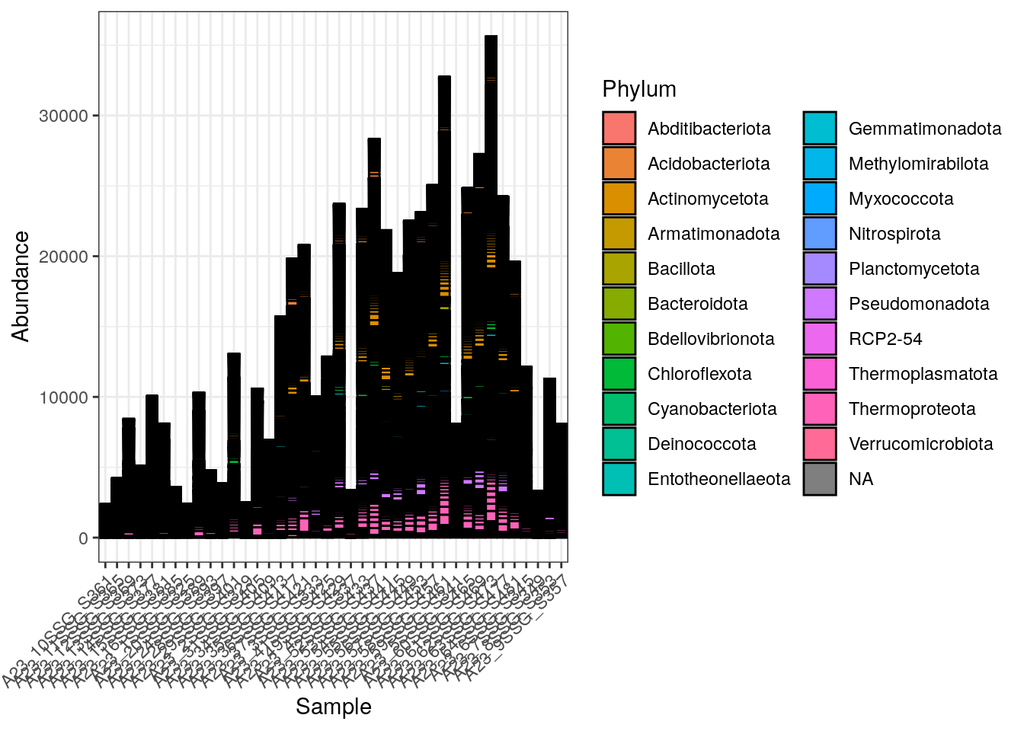

```r
##first an abundance plot
subset <- subset_samples(ps,  (SampleDate  == "Aug_2023") & (Microhabitat == "SSG") )
subset <- prune_taxa(taxa_sums(subset) > 100, subset)
plot_bar(subset, fill='Phylum')+theme_bw()+theme(axis.text.x = element_text(angle = 45, hjust=1))
```

```r
##some exact DNA sequences
head(refseq(ps))
```

```
## DNAStringSet object of length 6:
##     width seq                                               names
## [1]   253 TACCAGCACCCCGAGTGGTCGGG...TGAAAGCTGGGGGAGCAAACCGG ASV1
## [2]   253 TACGAAGGGGGCTAGCGTTGTTC...CGAAAGCGTGGGGAGCAAACAGG ASV2
## [3]   253 TACCAGCACCCCGAGTGGTCGGG...TGAAAGCTGGGGGAGCAAACCGG ASV3
## [4]   253 TACGTAGGGGGCGAGCGTTGTCC...CGAAAGCGTGGGGAGCAAACAGG ASV4
## [5]   253 TACGTAGGGTGCAAGCGTTGTCC...CGAAAGCGTGGGGAGCGAACAGG ASV5
## [6]   253 TACGGAGGGGGTTAGCGTTGTTC...CGAAAGCGTGGGGAGCAAACAGG ASV6
```

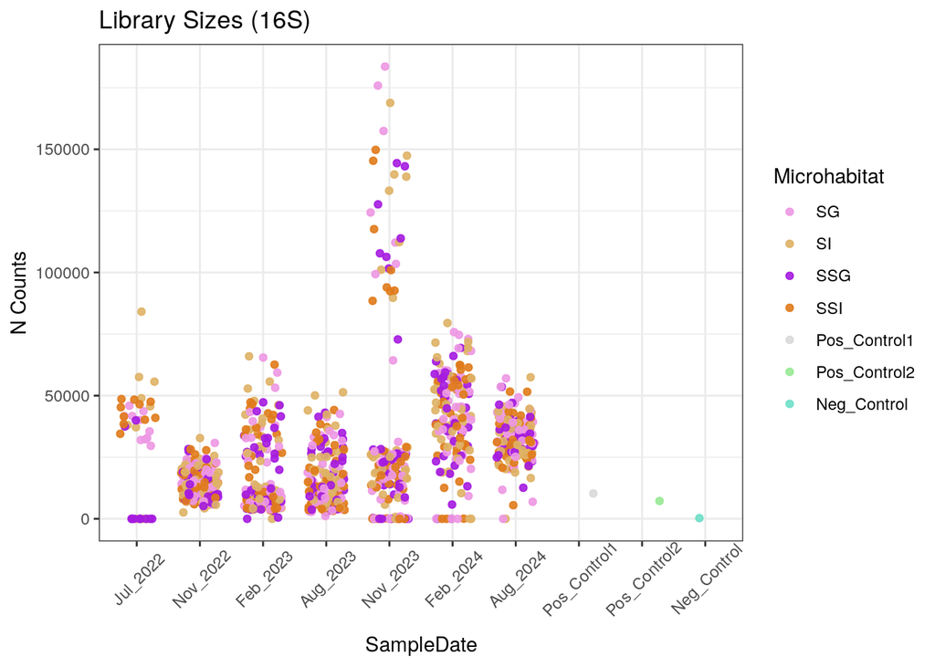

```r
##then check the library sizes
gdat <- tibble(ncounts=sample_sums(ps), SampleID=sample_names(ps))
gdat <- left_join(meta, gdat, by='SampleID')
gdat <- gdat %>% mutate(SampleDate=factor(SampleDate,
                                          levels=c("Jul_2022", "Nov_2022" ,
                                                   "Feb_2023", "Aug_2023", "Nov_2023",
                                                   "Feb_2024", "Aug_2024",
                                                   "Pos_Control1","Pos_Control2","Neg_Control"))) %>%
                mutate(Microhabitat=factor(Microhabitat, levels=c("SG","SI","SSG","SSI",
                                                                  "Pos_Control1","Pos_Control2","Neg_Control")))
#library sizes by timepoint and microhabitat
ggplot(gdat)+
  geom_jitter(aes(x=SampleDate, y=ncounts, color=Microhabitat), width = .3, height=.3, alpha=0.9)+
  theme_bw()+
  theme(axis.text.x = element_text(angle=45, vjust=.67, hjust=.5))+
  ggtitle('Library Sizes (16S)')+
  ylab('N Counts')+
  scale_color_manual(values = c('#ed98e3','#deb266','#a51be0','#e07b1b',
                                '#d9d9d9','#98e895','#6fdec8'))
```

First we make an abundance plot. We begin by choosing samples that are specific to Aug 2023 from the SSG microhabitat.

Next, we take a look at the exact sequences available in the phyloseq object and confirm they are the right length and show some level of conservation between sequences.

Lastly, we graph the library sizes of the data. There is a somewhat large variance in library size that is evident. This variation is why rarefaction is so important with this dataset.